# 52414 - lab 1

### Q3

### Preparing and Analyzing the World Bank Data

25 points a. Rename the columns of `eco_data`: `country,S_country,feature,feature_code,Y2018V,Y2019V`. (2pts)  
b. Create a new `eco` data-frame whose dimensions are $N \times 11$, where `N` is the number of countries. The first column should include the names of the countries in `eco_data.`  
The rest of the columns should be the features with their respective values in `eco_data` for each country from 2018. Print the head of the new data-frame.(8pts).  
In other words, in this question you are asked to create a new eco data-frame whose dimensions are $N \times 11$, where N is the number of countries (the first column should include the names of the countries in `eco_data`). The rest of the columns should be the features with their respective values in eco_data for each country from 2018. Print the head of the new data-frame. You may delete rows with NA as a country value only.  
c. Select and rename the following columns: `country` as country, `GDP(US currency)` as GDP, `Population ages 65 and above (% of total population)` as pop65, `Population in the largest city (% of urban population)` as pop_city_ratio, `Population, total` as pop_total columns . (2pts) d. Show a table of the five countries with the highest per capita GDP in 2018.  
Next (considering all countries), plot the % of population over 65 vs. log of GDP per capita in 2018, after excluding the 10% countries with the lowest GDP per capita. Using `lm` and `abline`, add a regression line to the plot. What is your conclusion? (13 pts)

**Solution:**

```r
# Q3 - a

#loading the `eco_data`:
eco_data <- read.csv(url("https://raw.githubusercontent.com/DataScienceHU/DataAnalysisR_2020/master/data/economic_data.csv"))

names(eco_data)[1:6] <- c("country","S_country","feature","feature_code","Y2018V","Y2019V")


# Q3 - b
eco_data = head(eco_data, -5) # delete the last 5 rows, empty rows.
eco_data.slice <- eco_data[,c(1,3,5)] # new data fram just with require coulums
eco_data.wide <- reshape(eco_data.slice, idvar = "country", timevar = "feature", direction = "wide") # caonvert to wide format
head(eco_data.wide)
```

```
##           country Y2018V.GDP (current US$) Y2018V.GDP (constant LCU)
## 1     Afghanistan         19362969582.3643          511432475534.156
## 11        Albania          15102500898.238             1513259270000
## 21        Algeria          173757952824.25          6123376375970.86
## 31 American Samoa                636000000                 608000000
## 41        Andorra         3236543909.34844                2002840000
## 51         Angola          105750987618.63             1552771000000
##    Y2018V.GDP, PPP (current international $)
## 1                           72672245387.0863
## 11                          38306694289.2319
## 21                          653771569286.319
## 31                                        ..
## 41                                        ..
## 51                          198795526982.065
##    Y2018V.Unemployment, female (% of female labor force) (modeled ILO estimate)
```

[output cut: 48 more lines]

```r
# Q3 - c

# select the columns required
eco_data.wide.select <-eco_data.wide %>% select(1, 2, 8, 9, 11)

#rename the columns name
names(eco_data.wide.select) = c("country", "GDP", "pop_total_columns", "pop_city_ratio", "pop65")



# Q3 - d
# Add new column that represent the GDP per capita,
eco_data.GDP.capita <- eco_data.wide.select %>% mutate(GDP_Capite = as.numeric(GDP) / as.numeric(pop_total_columns), pop_per = as.numeric(pop65) / as.numeric(pop_total_columns))
eco_data.GDP.capita %>% head(5)
```

```
##          country              GDP pop_total_columns   pop_city_ratio
## 1    Afghanistan 19362969582.3643          37172386 42.3311983623682
## 2        Albania  15102500898.238           2866376 27.5063925379807
## 3        Algeria  173757952824.25          42228429 8.78230990288061
## 4 American Samoa        636000000             55465               ..
## 5        Andorra 3236543909.34844             77006               ..
##              pop65 GDP_Capite     pop_per
## 1 2.58492693988024  0.4530059 0.513124471
## 2 13.7447359109736  0.4215909 0.311363636
## 3 6.36249654497986  0.3311594 1.223913043
## 4               ..  1.0801974 0.001233806
## 5               ..  0.5811380 0.001053741
```

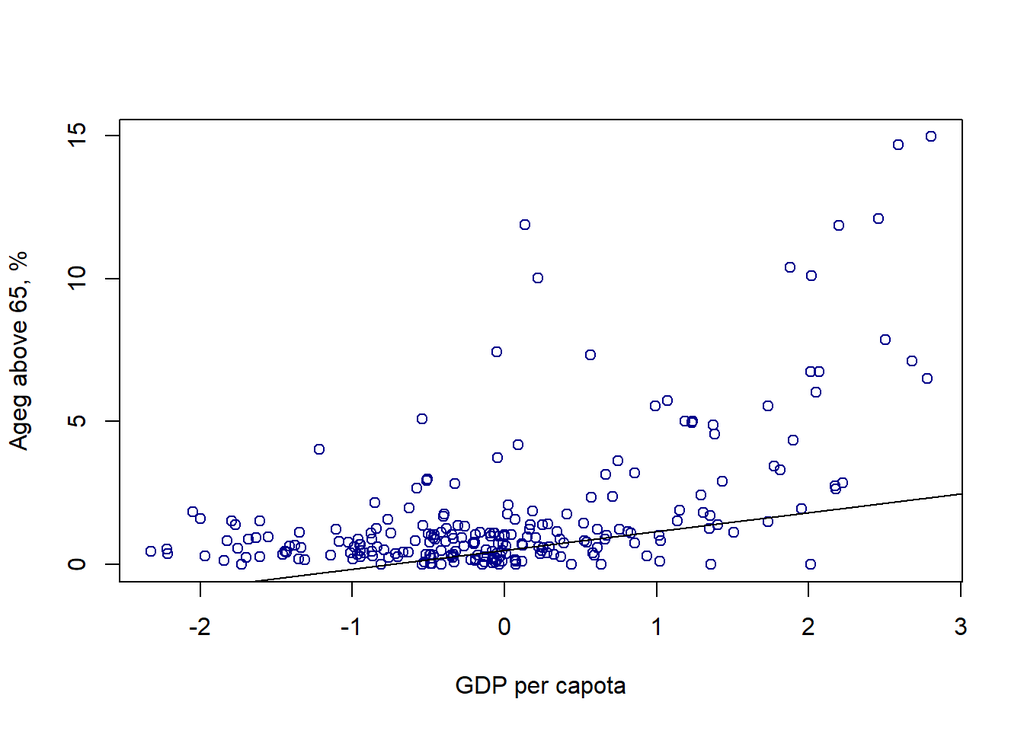

```r
eco_data.GDP.capita.ordered <- eco_data.GDP.capita[order(-eco_data.GDP.capita$GDP_Capite),]
eco_data.GDP.capita.ordered.d <- eco_data.GDP.capita.ordered %>% filter(GDP_Capite > quantile(GDP_Capite, 0.1))

plot(log(as.numeric(eco_data.GDP.capita.ordered.d$GDP_Capite)), as.numeric(eco_data.GDP.capita.ordered.d$pop_per), xlab = "GDP per capota", ylab = "Ageg above 65, %", col = "darkblue")
abline(lm(eco_data.GDP.capita.ordered.d$pop_per ~ eco_data.GDP.capita.ordered.d$GDP_Capite))
```